# 데이터 시각화

Author

이상일, 전혜민, 김세창, 김우형

Published

July 26, 2025

# 1 `ggplot2` 패키지

`ggplot2` 패키지는 R에서 시각화를 위해 가장 널리 사용되는 패키지 중 하나로, 그래픽 문법(Grammar of Graphics)을 바탕으로 유연하고 직관적인 그래프 생성을 가능하게 한다. 심미성 요소(aesthetics)와 기하적 요소(geometry)를 명확히 분리하고, 각 요소를 레이어(layer) 형태로 구성해 `+`로 연결함으로써 복잡한 시각화를 논리적으로 표현할 수 있다.

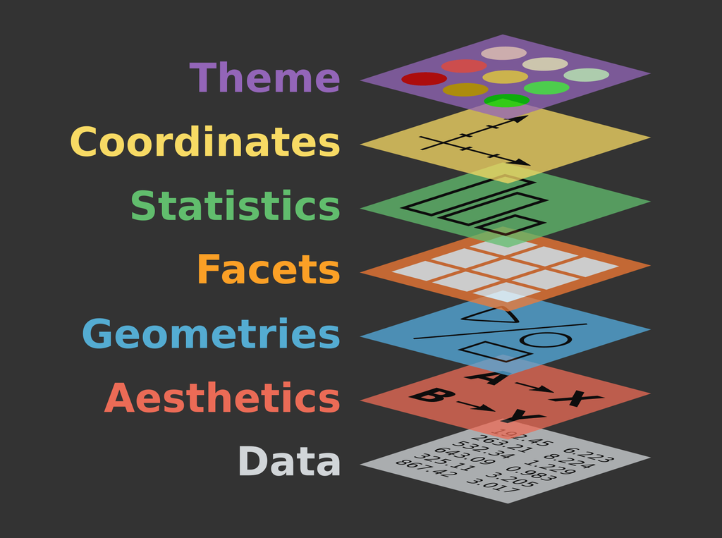

출처: https://r.qcbs.ca/workshop03/book-en/grammar-of-graphics-gg-basics.html

각 레이어에 대한 설명은 다음과 같다.

| 구성요소 | 설명 |
| --- | --- |
| 데이터(Data) | 시각화할 원데이터 |
| 심미성(Aesthetics) | 변수와 시각적 속성 간의 연결(x, y, color, size 등) |
| 기하(Geometries) | 실제 그래프 형태 |
| 면 분할(Facets) | 데이터를 하위 집합으로 나누어 여러 개의 소형 그래프로 표현 |
| 통계 변환(statistics) | 데이터에 대한 요약 또는 변환 |
| 좌표계(Coordinates) | 그래프의 좌표체계를 설정 |
| 테마(Theme) | 배경, 폰트, 제목, 축 등 비데이터적 시각 요소 |

# 2 핵심 레이어: 심미성과 기하

7개의 구성요소 중 가장 중요한 것은 `심미성(aesthetics)` 혹은 `심미성 매핑(aesthetic mapping)`과 `기하(geometries)` 혹은 `기하 객체(geometric objects)` 이다. 심미성은 전체적인 시각적 속성을 결정하고 기하는 그래프의 유형을 결정한다. 두 가지는 독립적인 요소이지만 어느 정도 관련되며, 특정 기하는 특정 심미성과만 결합할 수 있기도 하다. 예를 들어 포인트 기하 객체(`geom_point()`)는 크기(`size`) 심미성과 관련되지만, 라인폭(`linewidth`) 심미성과는 관련이 없다.